# Презентация по разделу №1 дополнительного курса

## Задание 15

Решение задания №15, при запуске firefox, откроется так скажем отдельный терминал внутри firefox, который закрывается через ctrl+c (рис. 30).

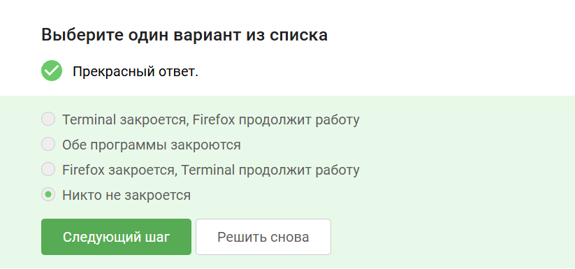

Рисунок 30: Решение №15

## Задание 16

Формулировка задания №16 (рис. 31).

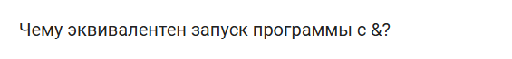

Рисунок 31: Задание №16

## Задание 16

Решение задания №16, запуск в фоновом режиме (рис. 32).

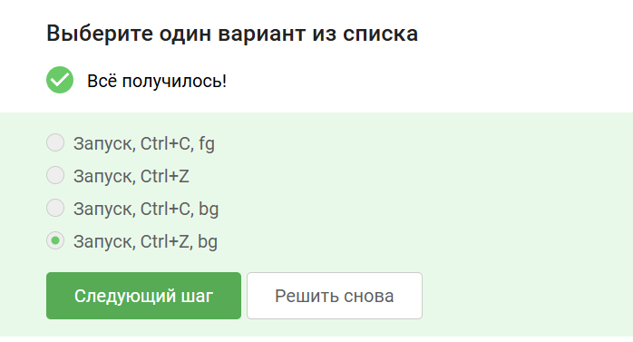

Рисунок 32: Решение №16

## Задание 17

Формулировка задания №17 (рис. 33).

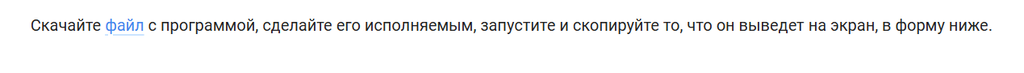

Рисунок 33: Задание №17

## Задание 17

Решение задания №17, сделал исполняемым файл через chmod +x (рис. 34).

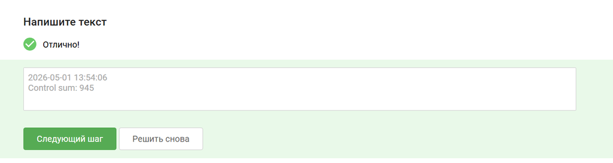

Рисунок 34: Решение №17

## Задание 18

Формулировка задания №18 (рис. 35).

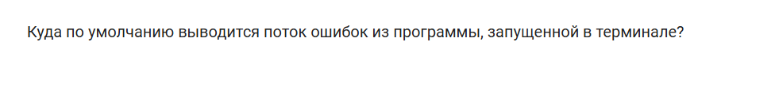

Рисунок 35: Задание №18

## Задание 18

Решение задания №18 (рис. 36).

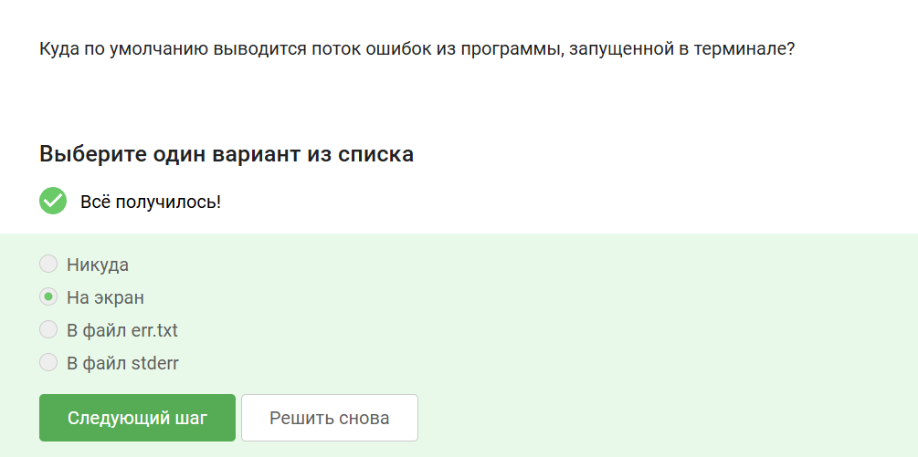

Рисунок 36: Решение №18

## Задание 19

Формулировка задания №19 (рис. 37).

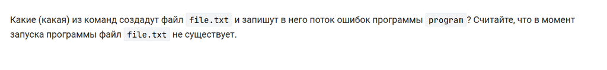

Рисунок 37: Задание №19

## Задание 19

Решение задания №19, ответы с < неверны, вариант без “2” неверен, тк не создаст файл (рис. 38).

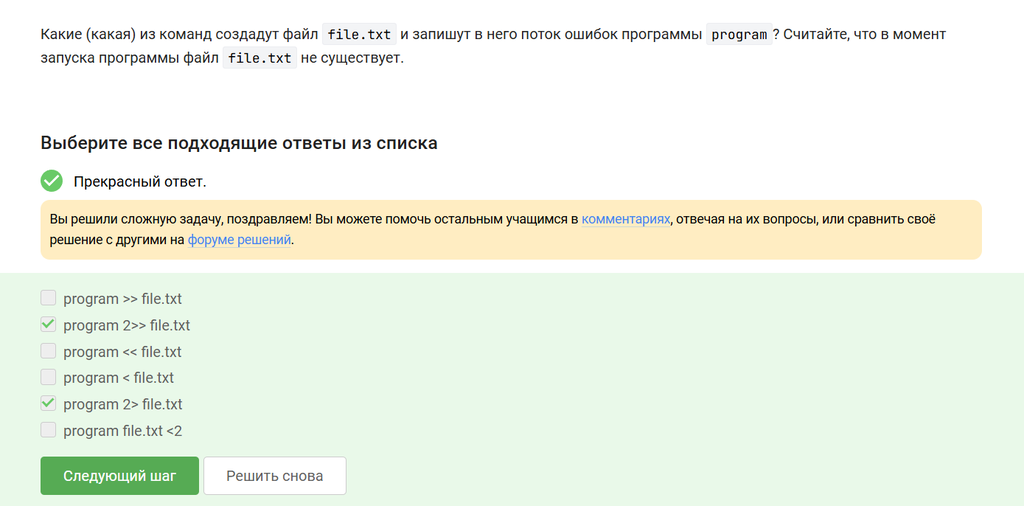

Рисунок 38: Решение №19

## Задание 20

Формулировка задания №20 (рис. 39).

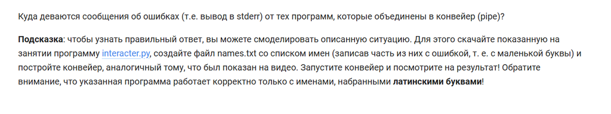

Рисунок 39: Задание №20

## Задание 20

Решение задания №20 (рис. 40).

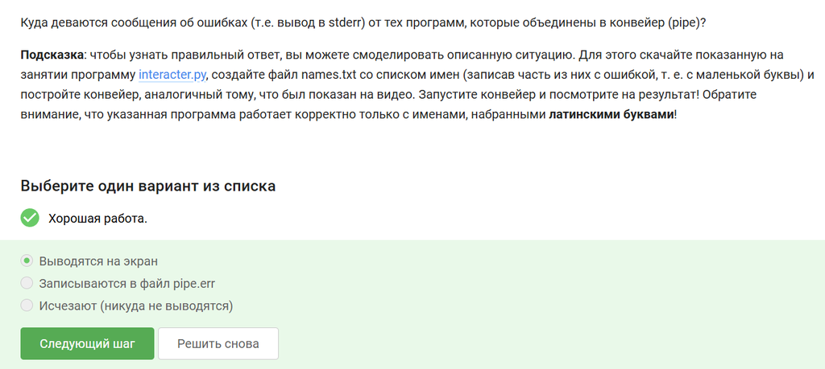

Рисунок 40: Решение №20

## Задание 21

Формулировка задания №21 (рис. 41).

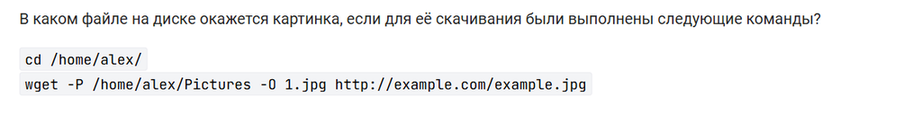

Рисунок 41: Задание №21

## Задание 21

Решение задания №21, флаг -O записывает введённое название в текущий каталог, игнорируя -P (рис. 42).

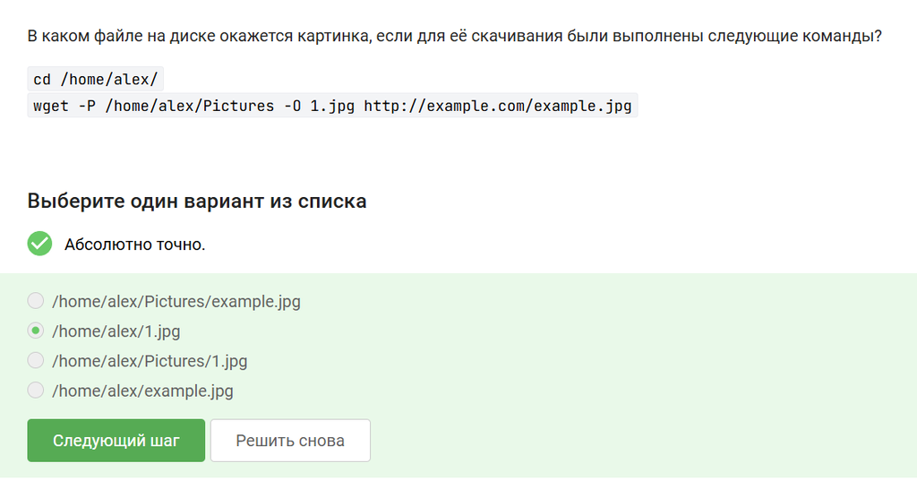

Рисунок 42: Решение №21

## Задание 22

Формулировка задания №22 (рис. 43).

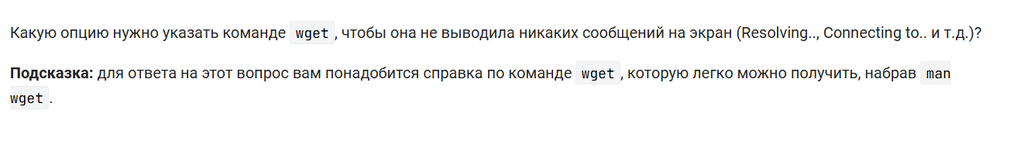

Рисунок 43: Задание №22

## Задание 22

Решение задания №22 (рис. 44).

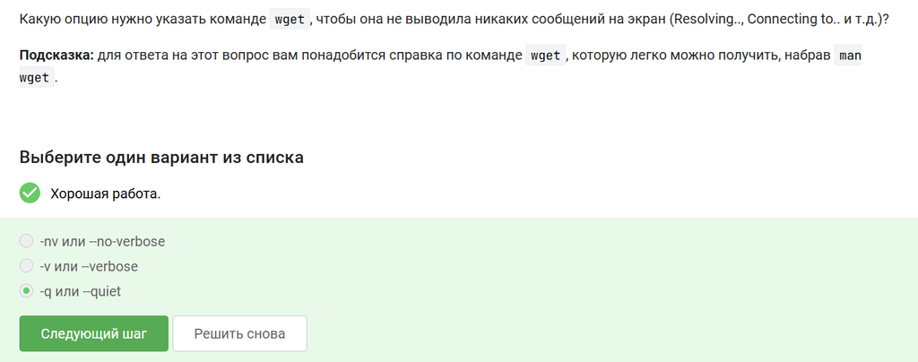

Рисунок 44: Решение №22

## Задание 23

Формулировка задания №23 (рис. 45).

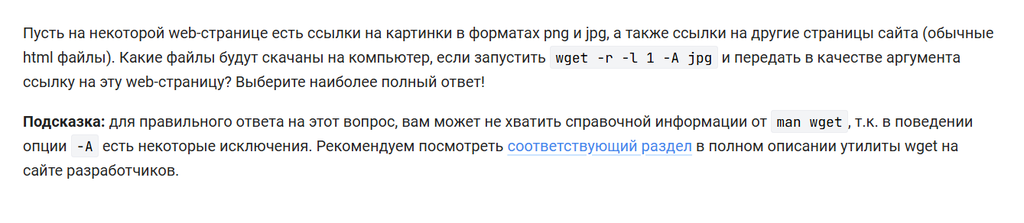

Рисунок 45: Задание №23

## Задание 23

Решение задания №23 (рис. 46).

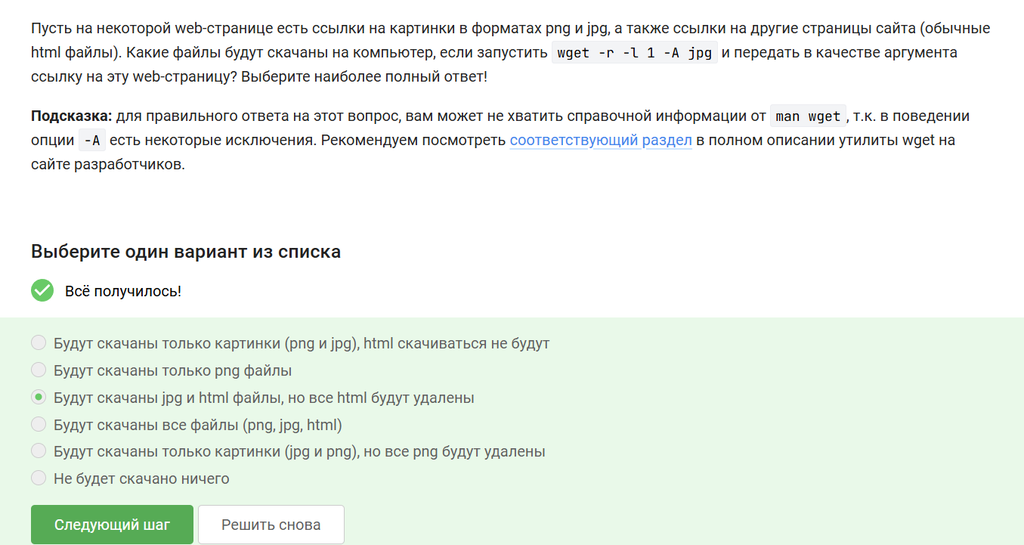

Рисунок 46: Решение №23

## Задание 24

Формулировка задания №24 (рис. 47).

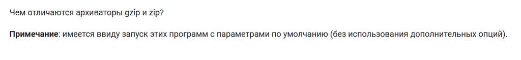

Рисунок 47: Задание №24

## Задание 24

Решение задания №24 (рис. 48).

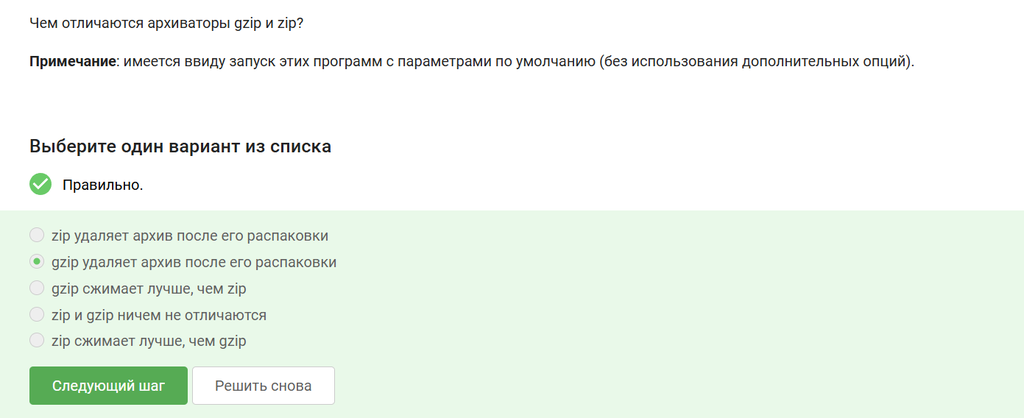

Рисунок 48: Решение №24

## Задание 25

Формулировка задания №25 (рис. 49).

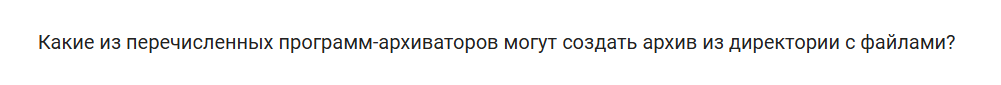

Рисунок 49: Задание №25

## Задание 25

Решение задания №25 (рис. 50).

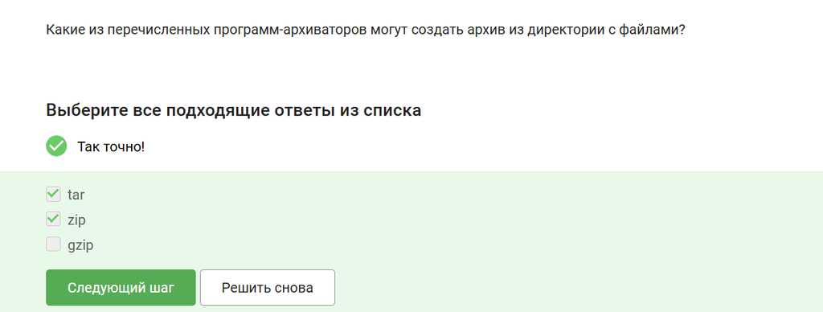

Рисунок 50: Решение №25

## Задание 26

Формулировка задания №26 (рис. 51).

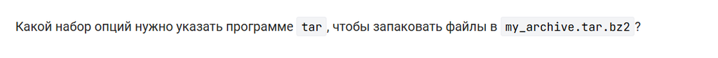

Рисунок 51: Задание №26

## Задание 26

Решение задания №26 (рис. 52).

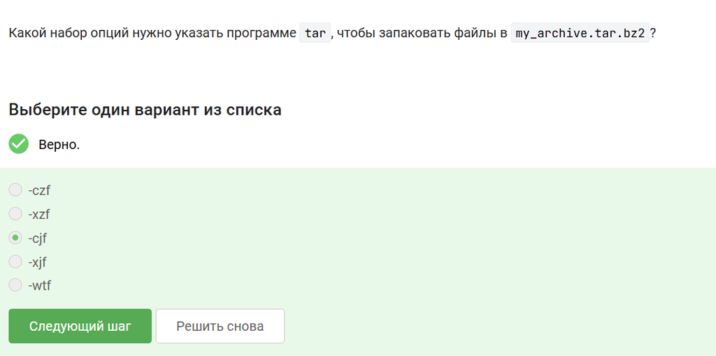

Рисунок 52: Решение №26

## Задание 27

Формулировка задания №27 (рис. 53).

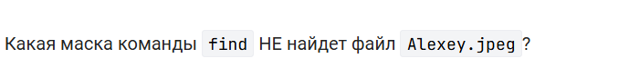

Рисунок 53: Задание №27

## Задание 27

Решение задания №27, маленькая буква, неверный формат, ? ищет только 1 символ (рис. 54).

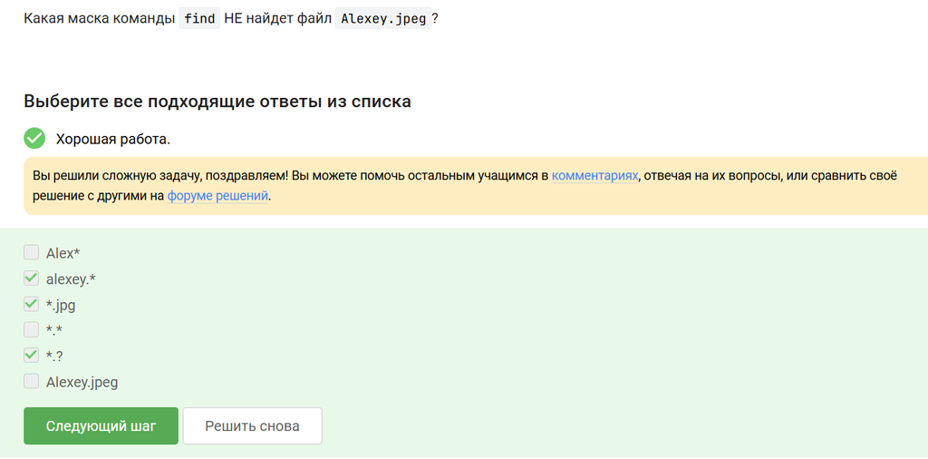

Рисунок 54: Решение №27

## Задание 28

Формулировка задания №28 (рис. 55).

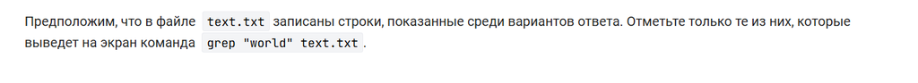

Рисунок 55: Задание №28

## Задание 28

Решение задания №28, регистр учитывается (рис. 56).

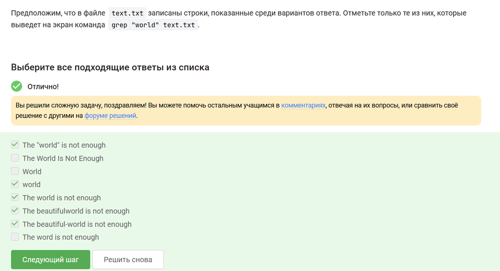

Рисунок 56: Решение №28

## Задание 29

Формулировка задания №29 (рис. 57).

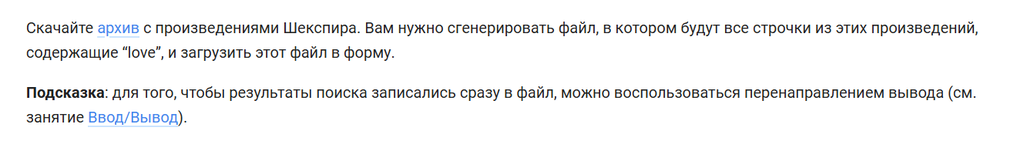

Рисунок 57: Задание №29

## Задание 29

Решение задания №29, grep -Fr “love” Shakespeare/* > temp.txt (рис. 58).

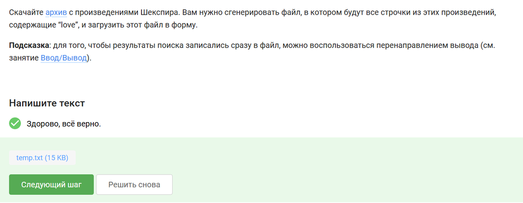

Рисунок 58: Решение №29

# Выводы

## Выводы

В процессе проделанной работы я приобрёл практические навыки работы с Linux и прошёл 1-ый раздел курса “Введение в Linux” на Stepik.